# Training Word Vectors

This exercise will create a word vectors using the gensim library. Source of document obtained from Project Gutenberg.

```python
import re
import requests
import json
from gensim.summarization import textcleaner
from gensim.utils import simple_preprocess
from gensim.models import Word2Vec
import matplotlib.pyplot as plt
%matplotlib inline
```

```python
with open('data_ch7/ProjectGutenbergBooks.json','r') as f:
    catalog=json.load(f)
```

```python
catalog
```

```
[{'title': 'Pride and Prejudice', 'author': 'Jane Austen', 'id': 1342},
 {'title': 'A Christmas Carol in Prose',
  'author': 'Charles Dickens',
  'id': 46},
 {'title': 'A Tale of Two Cities', 'author': 'Charles Dickens', 'id': 98},
 {'title': 'Frankenstein; Or, The Modern Prometheus',
  'author': 'Mary Wollstonecraft Shelley',
  'id': 84},
 {'title': 'Dracula', 'author': 'Bram Stoker', 'id': 345},
 {'title': 'Heart of Darkness', 'author': 'Joseph Conrad', 'id': 219},
 {'title': 'Moby Dick; Or, The Whale',
  'author': 'Herman Melville',
  'id': 2701},
 {'title': "Alice's Adventures in Wonderland",
  'author': 'Lewis Carroll',
  'id': 11},
 {'title': 'The Adventures of Sherlock Holmes',
  'author': 'Arthur Conan Doyle',
  'id': 1661},
 {'title': 'A Modest Proposal', 'author': 'Jonathan Swift', 'id': 1080}]
```

```python
book_url='https://gutenberg.org/files/{}/{}-0.txt'
def load_book(book_id):
    url=book_url.format(book_id, book_id)
    contents=requests.get(url).text
    clean_contents=re.sub(r'\r\n',' ',contents)
    return clean_contents
```

```python
book_ids=[book['id'] for book in catalog]
books=[load_book(id) for id in book_ids]
```

Before training word vectors, we need to break the books into a list of documents.

```python
def to_sentences(book):
    sentences=textcleaner.split_sentences(book) # split text and get the list of sentences from given text.
    sentence_tokens=[simple_preprocess(sentence) for sentence in sentences] #converts documents into a list of lowercase tokens
    return sentence_tokens
```

```python
book_sentences=[to_sentences(b) for b in books]
documents=[sent for book_sent in book_sentences for sent in book_sent]
```

```python
len(documents)
```

```
32541
```

Train Word2Vec model

```python
model=Word2Vec(documents, size=100, window=10, min_count=2,workers=10)
model.train(documents, total_examples=len(documents), epochs=50)
```

```
(27521156, 37184550)
```

The trained word vectors get stored in model.wv, which is instance of KeyedVectors, Now make use of most_similar() func of the model.wv instance to find the similar words.

```python
model.wv.most_similar(positive='worst')
```

```
[('best', 0.447860449552536),
 ('purest', 0.4259404242038727),
 ('devilry', 0.4108991324901581),
 ('truest', 0.40112441778182983),
 ('regarding', 0.38611769676208496),
 ('reward', 0.3725556433200836),
 ('race', 0.37105894088745117),
 ('pays', 0.36665448546409607),
 ('dispose', 0.3650950491428375),
 ('brutal', 0.36470362544059753)]
```

Create a func to display the vector.

```python
def show_vector(word):
    vector=model.wv[word]
    fig, ax = plt.subplots(1,1, figsize=(10,2))
    ax.tick_params(axis='both', which='both', left=False,
                  bottom=False, top=False, labelleft=False, labelbottom=False)
    ax.grid(False)
    print(word)
    ax.bar(range(len(vector)), vector, 0.5)
```

```
sad
```

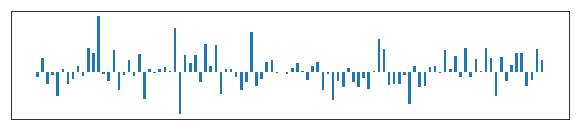

```python
show_vector('sad')
```

```
best
```

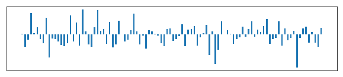

```python
show_vector('best')
```

# Using pre-trained word vectors

Once the word vectors have been trained on a language source and used in a project, they can be stored and reused for other related projects, certain factors such as the training source, the number of words, and context in which they were used taken into considerarion. This application of training from one project to another is known as transfer-learning.

- Pre-trained word vectors can get pretty large. For example, vectors trained on the Google News contain 3 millions words. It's compressed size is 1.5 GB.

```python
# Load pre-trained word vectors
import numpy as np
import contractions
import zipfile
```

```python
glove_dir ='data_ch6/glove/'
glove_zip = glove_dir + 'glove.6B.50d.zip'
zip_ref=zipfile.ZipFile(glove_zip,'r')
zip_ref.extractall(glove_dir)
zip_ref.close()
```

```python
def load_glove_vectors(fn):
    print('Loading glove Model')
    with open(fn, 'r', encoding='utf8')as glove_vector_file:
        model={}
        for line in glove_vector_file:
            parts=line.split()
            word=parts[0]
            embedding=np.array([float(val) for val in parts[1:]])
            model[word]=embedding
        print('Loaded {} words'.format(len(model)))
    return model
```

```python
glove_vectors=load_glove_vectors('data_ch6/glove/glove.6B.50d.txt')
```

```
Loading glove Model
Loaded 400000 words
```

```python
glove_vectors
# mappings of the words to the vectors, access the vector for a word, which return a 50-dimensional vector.
```

[output not shown]

[output cut: 9441 more lines]

[output not shown]

```python
glove_vectors['dog']
```

```
array([ 0.11008  , -0.38781  , -0.57615  , -0.27714  ,  0.70521  ,
        0.53994  , -1.0786   , -0.40146  ,  1.1504   , -0.5678   ,
        0.0038977,  0.52878  ,  0.64561  ,  0.47262  ,  0.48549  ,
       -0.18407  ,  0.1801   ,  0.91397  , -1.1979   , -0.5778   ,
       -0.37985  ,  0.33606  ,  0.772    ,  0.75555  ,  0.45506  ,
       -1.7671   , -1.0503   ,  0.42566  ,  0.41893  , -0.68327  ,
        1.5673   ,  0.27685  , -0.61708  ,  0.64638  , -0.076996 ,
        0.37118  ,  0.1308   , -0.45137  ,  0.25398  , -0.74392  ,
       -0.086199 ,  0.24068  , -0.64819  ,  0.83549  ,  1.2502   ,
       -0.51379  ,  0.04224  , -0.88118  ,  0.7158   ,  0.38519  ])
```

```python
def word_vectors(glove_vectors, word):
    vector=glove_vectors.get(word.lower()) # Find a word and convert it into lower case
    if vector is None:
        vector=[0]*50
    return vector

def to_image(vector, word=''):
    fig, ax=plt.subplots(1,1)
    ax.tick_params(axis='both', which='both', left=False,
                  bottom=False, top=False, labelleft=False, labelbottom=False)
    ax.grid(False)
    ax.bar(range(len(vector)), vector, 0.5)
    ax.text(s=word, x=1, y=vector.max()+0.5)
    return vector
```

```
array([-0.094386,  0.43007 , -0.17224 , -0.45529 ,  1.6447  ,  0.40335 ,
       -0.37263 ,  0.25071 , -0.10588 ,  0.10778 , -0.10848 ,  0.15181 ,
       -0.65396 ,  0.55054 ,  0.59591 , -0.46278 ,  0.11847 ,  0.64448 ,
       -0.70948 ,  0.23947 , -0.82905 ,  1.272   ,  0.033021,  0.2935  ,
        0.3911  , -2.8094  , -0.70745 ,  0.4106  ,  0.3894  , -0.2913  ,
        2.6124  , -0.34576 , -0.16832 ,  0.25154 ,  0.31216 ,  0.31639 ,
        0.12539 , -0.012646,  0.22297 , -0.56585 , -0.086264,  0.62549 ,
       -0.0576  ,  0.29375 ,  0.66005 , -0.53115 , -0.48233 , -0.97925 ,
        0.53135 , -0.11725 ])
```

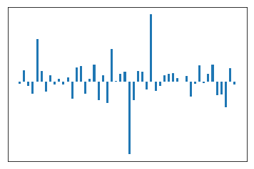

```python
man=to_image(word_vectors(glove_vectors,'man'))
man
```

```
array([-1.8153e-01,  6.4827e-01, -5.8210e-01, -4.9451e-01,  1.5415e+00,
        1.3450e+00, -4.3305e-01,  5.8059e-01,  3.5556e-01, -2.5184e-01,
        2.0254e-01, -7.1643e-01,  3.0610e-01,  5.6127e-01,  8.3928e-01,
       -3.8085e-01, -9.0875e-01,  4.3326e-01, -1.4436e-02,  2.3725e-01,
       -5.3799e-01,  1.7773e+00, -6.6433e-02,  6.9795e-01,  6.9291e-01,
       -2.6739e+00, -7.6805e-01,  3.3929e-01,  1.9695e-01, -3.5245e-01,
        2.2920e+00, -2.7411e-01, -3.0169e-01,  8.5286e-04,  1.6923e-01,
        9.1433e-02, -2.3610e-02,  3.6236e-02,  3.4488e-01, -8.3947e-01,
       -2.5174e-01,  4.2123e-01,  4.8616e-01,  2.2325e-02,  5.5760e-01,
       -8.5223e-01, -2.3073e-01, -1.3138e+00,  4.8764e-01, -1.0467e-01])
```

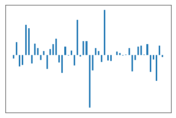

```python
woman=to_image(word_vectors(glove_vectors,'woman'))
woman
```

```
array([ 0.50451 ,  0.68607 , -0.59517 , -0.022801,  0.60046 , -0.13498 ,
       -0.08813 ,  0.47377 , -0.61798 , -0.31012 , -0.076666,  1.493   ,
       -0.034189, -0.98173 ,  0.68229 ,  0.81722 , -0.51874 , -0.31503 ,
       -0.55809 ,  0.66421 ,  0.1961  , -0.13495 , -0.11476 , -0.30344 ,
        0.41177 , -2.223   , -1.0756  , -1.0783  , -0.34354 ,  0.33505 ,
        1.9927  , -0.04234 , -0.64319 ,  0.71125 ,  0.49159 ,  0.16754 ,
        0.34344 , -0.25663 , -0.8523  ,  0.1661  ,  0.40102 ,  1.1685  ,
       -1.0137  , -0.21585 , -0.15155 ,  0.78321 , -0.91241 , -1.6106  ,
       -0.64426 , -0.51042 ])
```

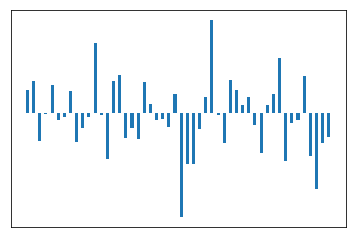

```python
king=to_image(word_vectors(glove_vectors,'king'))
king
```

```
array([ 0.090698,  0.61027 , -0.71676 , -0.02657 ,  0.24787 ,  0.13825 ,
       -0.58088 ,  0.095216, -0.42528 , -0.25552 , -0.71017 , -0.57314 ,
        0.27204 , -0.41773 , -0.22506 ,  0.026542,  0.019901,  0.5384  ,
       -0.60238 ,  0.45938 ,  0.45656 ,  0.022261, -0.60468 ,  1.2162  ,
       -0.90259 , -1.1668  ,  0.27097 ,  0.24491 , -0.3759  , -1.1213  ,
        0.78677 ,  0.28596 ,  0.40293 , -0.97438 ,  0.69444 , -0.04297 ,
        0.25991 , -0.20318 ,  0.45115 , -0.32781 , -0.69681 ,  0.035623,
       -0.088427,  0.42531 , -0.12019 ,  0.62923 , -0.088203, -1.5211  ,
        0.34276 ,  0.097266])
```

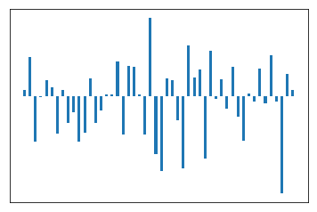

```python
queens=to_image(word_vectors(glove_vectors,'queens'))
queens
```

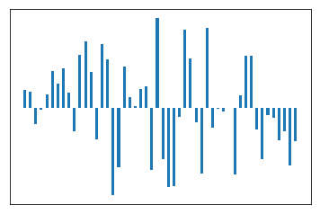

```python
combine=to_image(king-man+woman-queens)
```

# Document Vectors

```python
import pandas as pd
from gensim import utils
from gensim.models.doc2vec import TaggedDocument
from gensim.models import Doc2Vec
from gensim.parsing.preprocessing import preprocess_string, remove_stopwords
import random
```

```python
pd.set_option('display.max_colwidth', -1)
```

```python
movie_lines_file='data_ch7/cornell-movie-dialogs/movie_lines.txt'
```

```python
with open(movie_lines_file) as f:
    movie_lines=[line.strip().split('+++$+++') for line in f.readlines()]
df=pd.DataFrame([{'LineNumber': d[0].strip(),
                 'Person': d[3].strip(),
                  'Line': d[4].strip(),
                 'Movie': d[2].strip()} for d in movie_lines])
df=df.set_index('LineNumber')
```

```python
df.head()
```

| LineNumber | Line | Movie | Person |
| --- | --- | --- | --- |
| L1045 | They do not! | m0 | BIANCA |
| L1044 | They do to! | m0 | CAMERON |
| L985 | I hope so. | m0 | BIANCA |
| L984 | She okay? | m0 | CAMERON |
| L925 | Let's go. | m0 | BIANCA |

```python
len(df)
```

```
304713
```

```python
df.nunique()
```

```
Line      265786
Movie     617
Person    5356
dtype: int64
```

Draw sample sizes of 50000.

```python
samples=df.sample(50000)
```

```python
samples.head()
```

| LineNumber | Line | Movie | Person |
| --- | --- | --- | --- |
| L451119 | I'm sorry. That's very sweet, Edward, and I know you mean it... | m479 | VIVIAN |
| L62061 | What kind of work do you think you would be qualified for? | m254 | CLERK |
| L598175 | Jeanne... the man hasn't been paid for six months -- that's his only reward. Let him take a few teeth... | m565 | LA HIRE |
| L8215 | How long have you been awake? | m7 | DAN |
| L251120 | Now. You say the driveway's on your side of the house. So I guess you don't sleep in the same room. | m77 | BEN |

Create a class, the object of which will create the training instances for Doc2vec model.

```python
class DocumentDataset(object):
    def __init__(self, data:pd.DataFrame, column):
        document=data[column].apply(self.preprocess)
        self.documents=[TaggedDocument(text, [index]) for index, text in document.iteritems()]

    def preprocess(self, document):
        return preprocess_string(remove_stopwords(document))

    def __iter__(self):
        for document in self.documents:
            yield documents

    def tagged_documents(self, shuffle=False):
        if shuffle:
            random.shuffle(self.documents)
        return self.documents
```

```python
doc_dataset=DocumentDataset(samples, 'Line')
```

```python
doc_dataset
```

```
<__main__.DocumentDataset at 0x19e504ede10>
```

```python
docVecModel=Doc2Vec(min_count=1, window=5, vector_size=100, sample=1e-4, negative=5, workers=8)
docVecModel.build_vocab(doc_dataset.tagged_documents())
```

```python
docVecModel.train(doc_dataset.tagged_documents(shuffle=True), total_examples=doc_vec_model.corpus_count, epochs=10)
```

```python
docVecModel['L598175']
```

```
array([ 0.00266998, -0.00214804,  0.0100257 ,  0.0041798 , -0.00927539,
       -0.013732  ,  0.0082033 , -0.02561567,  0.00631446, -0.00195026,
       -0.00585379, -0.00407408,  0.00261047, -0.01728125,  0.01813742,
       -0.00360526,  0.0064688 , -0.00958272,  0.01245025, -0.00263103,
        0.00734843,  0.00885547,  0.00645458, -0.00037088, -0.00942434,
       -0.00594938,  0.00141447,  0.00581425, -0.01014053, -0.00959514,
       -0.00086512, -0.00803543,  0.00090155,  0.01377656,  0.00681712,
       -0.00100678,  0.00145237,  0.00357616, -0.00697568, -0.00542398,
        0.00290843,  0.01546435,  0.00446986,  0.007087  , -0.00113945,
        0.00953048,  0.0115152 ,  0.00050101, -0.00560055,  0.00055214,
        0.00237186,  0.00178061,  0.01824742,  0.00230147,  0.00288522,
        0.00201943,  0.00534189, -0.00231243, -0.00833196,  0.01401764,
        0.00877996, -0.00554807, -0.00309575, -0.01594381,  0.00300383,
       -0.01425109, -0.01473548,  0.00134294,  0.01494937, -0.01720436,
       -0.00563255, -0.00138243,  0.01120594,  0.00296073, -0.00272727,
        0.00706927, -0.00506314, -0.01996284, -0.00101423,  0.02931252,
       -0.00314127,  0.00928942, -0.01467926, -0.01214325, -0.00917454,
        0.01883664,  0.00396846, -0.00897227,  0.00728087, -0.00515436,
       -0.00726556,  0.01891953,  0.01685883,  0.00123698,  0.00496895,
       -0.00780857,  0.01222841,  0.01116768, -0.00726897,  0.01300528],
      dtype=float32)
```

```python
def show_charts(vector, line):
    fig, ax=plt.subplots(1,1, figsize=(10,2))
    ax.tick_params(axis='both', which='both', left=False,
                  bottom=False, top=False, labelleft=False, labelbottom=False)
    ax.grid(False)
    print(line)
    ax.bar(range(len(vector)), vector, 0.5)
```

```python
def show_movie_line(line_number):
    line=samples.ix['L598175'].Line
    doc_vector=doc_vec_model[line_number]
    show_charts(doc_vector, line)
```

```
Jeanne... the man hasn't been paid for six months -- that's his only reward.  Let him take a few teeth...
```

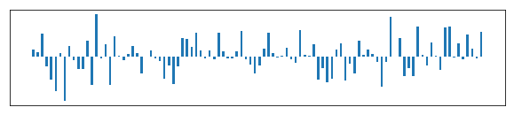

```python
show_movie_line('L598175')
```

Find a similar movie lines using document vectors

Re-load the trained document model named MovieLinesModel.d2v

```python
docVecModel=Doc2Vec.load('data_ch7/MovieLinesModel.d2v')
```

Create functions convert sentences into vectors and implement similarity checks

```python
def to_vector(sent):
    clean_sent=preprocess_string(sent)
    docVector=docVecModel.infer_vector(clean_sent)
    return docVector


def similar_movie_lines(sent):
    vector=to_vector(sent)
    similar_vectors=docVecModel.docvecs.most_similar(positive=[vector])
    similar_lines=[df.ix[line[0]].Line for line in similar_vectors]

    return similar_lines
```

```python
similar_movie_lines("Sure, that's easy. You gotta insult somebody.")
```

```
['Pack your shit! We gotta get outta here! We gotta get out!',
 "That goddamned woman. Thinks she can cart Jill off and leave me alone like this. I'm more than pissed, Margie. I'm a whole lot more than pissed. I been that plenty and I know the difference. This is different.",
 "Sure, that's easy.  You gotta insult somebody.",
 "Now see? Don't do that. I'll go along with all you say about me. But that... you can't pretend no more on that. Cuz I was just a kid, Momma.  I didn't know about any of that stuff he was doin' to me.  And you let him do it. Some big nobody in your life... and you let him do as he wanted... with th…
 "Nah, he's nothin'. It's just sometimes... sometimes you just gotta punch somebody out, y'know?",
 "Ruined a brand-new pair of Lee Press- ons.  Well, I sat down for a beer and KA- BLEWEY! Next thing I know, somethin' blows through my kitchen window. Next thing I know, I'm ass up in Loretta's flower bed.",
 "No, you listen. We're partners now and even though I'm running the show for you, I'm still running the show. That means I get a little respect. So I don't want to hear anymore of this Scooter, Buddy, Junior, Skippy, Tiger, bullshit. It's Jake.  And I gotta tell you, for a guy who spends all his ti…
 "You?  Don't make me laugh.  You can't take care of shit.  You've been dicking me around since we started on this turd-hunt.  All you're good for is games... So far, what I got outta you is nothin'...",
 "Wade, I got a message for you.  Jack Hewitt, he's looking for you. Wants you to clear your stuff out of his office in Town Hall.",
 "That's no mystery. Julio and Paolo brought it in,  You don't want to hurt those boys, do you? I mean, they sure as Hell have got something coming, but it ain't what the Law wants to give them. You understand?  No. How could you understand."]
```

```python
similar_movie_lines('What kind of work do you think you would be qualified for?')
```

```
["Where's Ronnie?",
 "No, no, it's my fault -- we didn't have a proper introduction ---",
 "Me.  This endless ...blonde babble. I'm like, boring myself.",
 'Esdras is a Jew.',
 "Even more reason to see him.  He'll be overjoyed with your success.",
 'We could not anticipate feline complications due to the reanimation process&emdash;',
 'Is it your dish?',
 'Mio caro Adone.',
 "You don't know how to hotwire.",
 'Helpless...']
```